# Checkpoint 4

Nicholas Di, Duc Ngo, Nolan Meyer

11/30/2021

# 1. Introducing your data

Our data includes financial information on companies in the S&P 500 stock index from 1999-2021. This information was scraped from Yahoo Finance in November of 2021, and collected in a csv format for data analysis. The information includes metrics like sales, earnings, cogs, stock price, and market sector. The goal is to analyze and model this data to better improve projections for a company’s future metrics, like earnings. The variables in the data set are described below:

[output not shown]

# 2. Data summaries

Demonstrate that you have the data imported and ready to go in RStudio. Specifically, to each dataset,applyandincludetheoutputforthefollowingfunctions:dim(), names(), head(), summary(). You do not need to write anything.

```r
dim(data)
```

```
## [1] 10062    24
```

```r
names(data)
```

```
##  [1] "YEAR"                "COMPANY"             "PRICE"
##  [4] "Sell"                "VOLUME"              "MARKET.CAP"
##  [7] "EARNINGS"            "COGS"                "SALES"
## [10] "CASH"                "INVESTMENTS"         "RECEIVABLE"
## [13] "INVENTORY"           "DEBTS"               "Name"
## [16] "Sector"              "CPALTT01USM657N_PC1" "GDP"
## [19] "GDP_PC1"             "T10Y2Y"              "M1SL_PC1"
## [22] "M1SL"                "Earnings_next_year"  "PROFIT"
```

```r
head(data)
```

```
##   YEAR COMPANY  PRICE    Sell    VOLUME  MARKET.CAP  EARNINGS      COGS
## 1 2021       A 127.69   0.000 303440000 38746254207 7.190e+08 2.502e+09
## 2 2020       A  68.92 125.034 309000000 21296279382 1.071e+09 2.358e+09
## 3 2019       A  81.56  82.642 314000000 25609839372 3.160e+08 2.227e+09
## 4 2018       A  64.43  81.851 321000000 20682030000 6.840e+08 2.063e+09
## 5 2017       A  53.20  67.793 322000000 17130400322 4.620e+08 2.005e+09
## 6 2016       A  40.31  52.517 326000000 13141060326 4.010e+08 1.997e+09
##       SALES      CASH INVESTMENTS RECEIVABLE INVENTORY    DEBTS
## 1 5.339e+09 1.441e+09           0  1.038e+09  7.20e+08 7.50e+07
## 2 5.163e+09 1.382e+09           0  9.300e+08  6.79e+08 6.16e+08
## 3 4.914e+09 2.247e+09           0  7.760e+08  6.38e+08 0.00e+00
## 4 4.472e+09 2.678e+09           0  7.240e+08  5.75e+08 2.10e+08
## 5 4.202e+09 2.289e+09           0  6.310e+08  5.33e+08 0.00e+00
## 6 4.038e+09 2.003e+09           0  6.060e+08  5.41e+08 0.00e+00
##                   Name      Sector CPALTT01USM657N_PC1       GDP GDP_PC1 T10Y2Y
## 1 Agilent Technologies Health Care                #N/A      #N/A    #N/A    1.2
## 2 Agilent Technologies Health Care               -39.9 20893.746    -2.2    0.5
## 3 Agilent Technologies Health Care                19.3 21372.582     4.1    0.2
## 4 Agilent Technologies Health Care                -9.3 20527.159     5.4    0.4
## 5 Agilent Technologies Health Care                 1.7 19479.623     4.2    0.9
## 6 Agilent Technologies Health Care               180.4 18695.106     2.7    1.0
##   M1SL_PC1    M1SL Earnings_next_year      PROFIT
## 1     #N/A    #N/A                 NA -100.000000
## 2    232.8 12792.9          7.190e+08   81.419046
## 3      4.5  3844.3          1.071e+09    1.326634
## 4      4.4  3680.4          3.160e+08   27.038643
## 5      8.5  3523.9          6.840e+08   27.430443
## 6      7.5  3248.5          4.620e+08   30.282807
```

```r
summary(data)
```

```
##       YEAR        COMPANY              PRICE               Sell
##  Min.   :1999   Length:10062       Min.   :   0.082   Min.   :   0.00
##  1st Qu.:2005   Class :character   1st Qu.:  22.235   1st Qu.:  20.44
##  Median :2011   Mode  :character   Median :  39.600   Median :  39.44
##  Mean   :2011                      Mean   :  64.213   Mean   :  64.04
##  3rd Qu.:2016                      3rd Qu.:  69.608   3rd Qu.:  70.83
##  Max.   :2021                      Max.   :3161.000   Max.   :3146.14
##
##      VOLUME            MARKET.CAP           EARNINGS
##  Min.   :7.082e+06   Min.   :2.600e+07   Min.   :-9.929e+10
##  1st Qu.:1.425e+08   1st Qu.:5.094e+09   1st Qu.: 1.580e+08
##  Median :2.947e+08   Median :1.197e+10   Median : 5.021e+08
##  Mean   :6.721e+08   Mean   :3.116e+10   Mean   : 1.466e+09
##  3rd Qu.:5.953e+08   3rd Qu.:2.741e+10   3rd Qu.: 1.372e+09
##  Max.   :2.617e+10   Max.   :2.053e+12   Max.   : 5.953e+10
##
##       COGS               SALES                CASH
##  Min.   :0.000e+00   Min.   :1.950e+05   Min.   :0.000e+00
##  1st Qu.:4.307e+08   1st Qu.:2.351e+09   1st Qu.:1.506e+08
##  Median :2.336e+09   Median :6.265e+09   Median :5.300e+08
##  Mean   :9.773e+09   Mean   :1.729e+10   Mean   :3.334e+09
##  3rd Qu.:7.464e+09   3rd Qu.:1.531e+10   3rd Qu.:1.737e+09
##  Max.   :4.203e+11   Max.   :5.592e+11   Max.   :5.276e+11
##
##   INVESTMENTS          RECEIVABLE          INVENTORY
##  Min.   :0.000e+00   Min.   :0.000e+00   Min.   :0.000e+00
##  1st Qu.:0.000e+00   1st Qu.:2.492e+08   1st Qu.:0.000e+00
##  Median :0.000e+00   Median :8.207e+08   Median :2.342e+08
##  Mean   :2.506e+09   Mean   :3.631e+09   Mean   :1.194e+09
##  3rd Qu.:1.870e+08   3rd Qu.:2.322e+09   3rd Qu.:1.049e+09
##  Max.   :4.207e+11   Max.   :4.164e+11   Max.   :8.172e+10
##
##      DEBTS               Name              Sector          CPALTT01USM657N_PC1
##  Min.   :0.000e+00   Length:10062       Length:10062       Length:10062
##  1st Qu.:1.000e+06   Class :character   Class :character   Class :character
##  Median :1.350e+08   Mode  :character   Mode  :character   Mode  :character
##  Mean   :1.769e+09
##  3rd Qu.:7.500e+08
##  Max.   :1.951e+11
##
##      GDP              GDP_PC1              T10Y2Y         M1SL_PC1
##  Length:10062       Length:10062       Min.   :-0.200   Length:10062
##  Class :character   Class :character   1st Qu.: 0.400   Class :character
##  Mode  :character   Mode  :character   Median : 1.200   Mode  :character
##                                        Mean   : 1.235
##                                        3rd Qu.: 2.000
##                                        Max.   : 2.500
##
##      M1SL           Earnings_next_year       PROFIT
##  Length:10062       Min.   :-9.929e+10   Min.   :-100.000
##  Class :character   1st Qu.: 1.725e+08   1st Qu.:  -8.097
##  Mode  :character   Median : 5.275e+08   Median :  11.152
##                     Mean   : 1.517e+09   Mean   :  13.471
##                     3rd Qu.: 1.428e+09   3rd Qu.:  30.956
##                     Max.   : 5.953e+10   Max.   :1145.168
##                     NA's   :500
```

# 3. Data viz

In your final report, elements such as data visualization will be just as important as the models you build. Construct and discuss a series of 4 data visualizations that inform your research questions. Combined, these viz should: • tell a story and follow a natural progression, starting with simple univariate plots and ending with multivariate plots; • help the readers better understand the structure of your data; and • inform the next step in your analysis: model building.

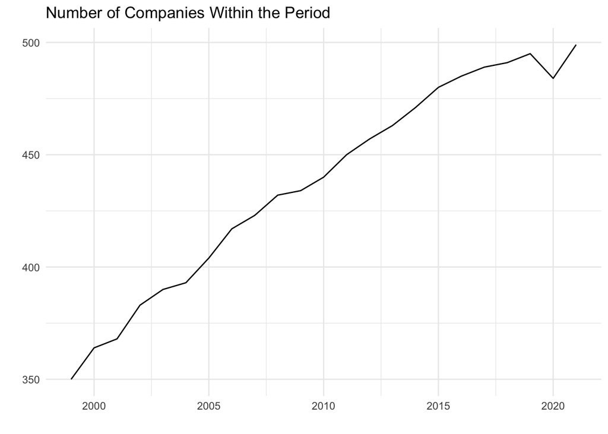

```r
#First Viz
tabyl(data$YEAR) %>%
  ggplot(aes(x= `data$YEAR`, y = n)) +
  geom_line()+
  xlab("")+
  ylab("") +
  labs(title = "Number of Companies Within the Period") +
  theme_minimal()
```

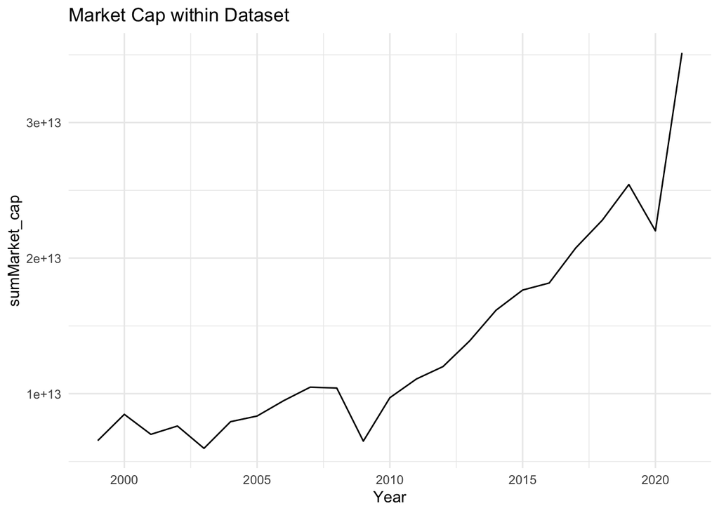

```r
#Second Viz
sumUSA <- data %>%
  group_by(YEAR) %>%
  summarise(sumMarket_cap = sum(`MARKET.CAP`),
            sumEarnings = sum(EARNINGS),
            sumCOGS = sum(COGS),
            sumSALES = sum(SALES),
            sumCASH = sum(CASH),
            sumInvestments = sum(INVESTMENTS),
            sumReceivable = sum(RECEIVABLE),
            sumInventory = sum(INVENTORY),
            sumDebts = sum(DEBTS))

sumUSA %>%
  ggplot(aes(x = YEAR, y = sumMarket_cap)) + geom_line() + theme_minimal() + labs(x = "Year") +
  ggtitle("Market Cap within Dataset")
```

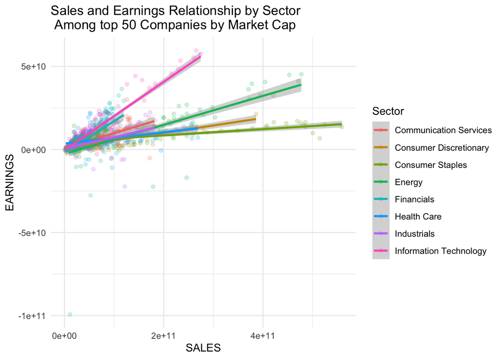

```r
#Third Viz
temp <- data %>%
  group_by(COMPANY) %>%
  summarize(count = n(),
            mean_MC = mean(MARKET.CAP)) %>%
  filter(count == 23) %>%
  arrange(desc(mean_MC)) %>%
  head(50)
temp <- temp$COMPANY
data_2 <- data %>%
  filter(COMPANY %in% temp)
data_2 %>%
  ggplot(aes(y = EARNINGS, x= SALES, color = Sector))+
  geom_point(alpha = 0.20)+
  geom_smooth(method = 'lm', formula = y ~ x)+
  theme_minimal()+
  ggtitle("Sales and Earnings Relationship by Sector \n Among top 50 Companies by Market Cap")
```

# 4. Model building

Build and analyze 1–3 Bayesian models which will help inform your research questions. (Build- ing 1 model will be worth full credit, but you’re encouraged to go beyond 1 model if possible.) Keep in mind: • Scaffolding is important! Model 1 should be the simplest model you can think of. You can build up from there, adding extra parameters/terms/layers as needed. THINK: is Y quantitative? Categorical? What’s a reasonable likelihood structure for our model? Are the data grouped? • For each model, define notation, specify the model, provide a brief model interpretation (eg: what do the parameters mean). • For each model, simulate the posterior in R and briefly summarize your conclusions.

Here, we have created three models: one model with the simple regression between Earnings_next_year with Earnings, one hierarchical model with earnings_next_year with earnings and the final model using bayesian forecasting.

```r
top_50 <- data %>%
  filter(YEAR == 2021) %>%
  arrange(EARNINGS)  %>%
  tail(50)

top_50 <- (top_50$COMPANY)

top_50 <- data %>%
    filter(COMPANY %in% top_50)
```

```r
top_50_update <- top_50 %>%
  drop_na()
```

### The first model:

```r
# Simulate the posterior
model_1 <- stan_glm(
  Earnings_next_year ~ EARNINGS, data = top_50_update,
  family = gaussian,
  prior_PD = FALSE,
  chains = 4, iter = 5000*2, seed = 84735, refresh = 0)
```

Here, we are trying to predict earnings_next_year using the information of earnings for the previous year. However, it did not generate a good result.

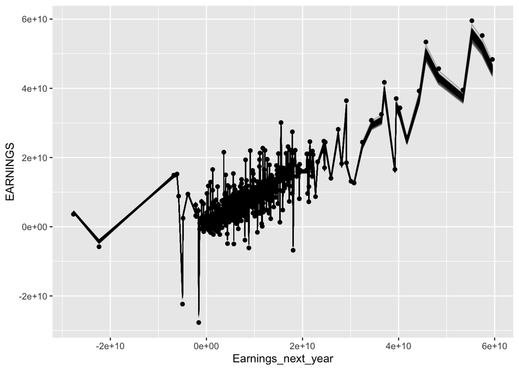

```r
# Plot 200 posterior plausible model lines
top_50_update %>%
  add_fitted_draws(model_1, n = 200) %>%
  ggplot(aes(x = Earnings_next_year, y = EARNINGS)) +
    geom_line(aes(y = .value, group = .draw), alpha = 0.15) +
    geom_point(data = top_50_update)
```

```r
tidy(model_1, effects = "fixed", conf.int = TRUE, conf.level = 0.80)
```

```
## # A tibble: 2 × 5
##   term        estimate std.error      conf.low conf.high
##   <chr>          <dbl>     <dbl>         <dbl>     <dbl>
## 1 (Intercept)  1.03e+9   1.59e+8 823538214.      1.23e+9
## 2 EARNINGS     9.16e-1   1.75e-2         0.894   9.39e-1
```

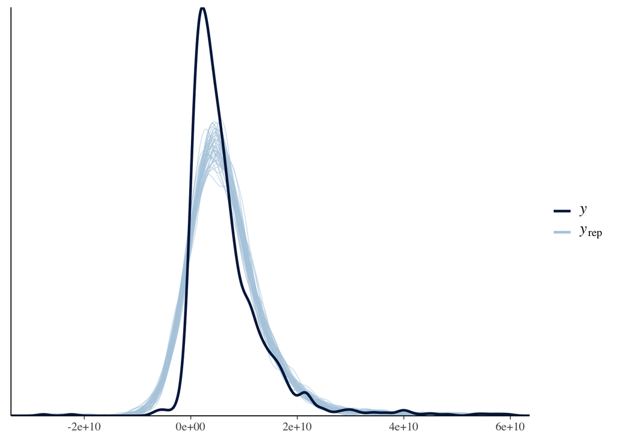

```r
pp_check(model_1)
```

The second model we think will be the hierarchical model with earnings_next_year and earnings.

```r
# Simulate the prior model
model_2_prior_with_hiar <- stan_glmer(
  Earnings_next_year ~ EARNINGS +  Sector + (1 | COMPANY), data = top_50_update,
  family = gaussian,
  chains = 4, iter = 5000*2, seed = 84735,
  prior_PD = TRUE)
# Check out the prior specifications
prior_summary(model_2_prior_with_hiar)
```

```
## Priors for model 'model_2_prior_with_hiar'
## ------
## Intercept (after predictors centered)
##   Specified prior:
##     ~ normal(location = 6.6e+09, scale = 2.5)
##   Adjusted prior:
##     ~ normal(location = 6.6e+09, scale = 1.9e+10)
##
## Coefficients
##   Specified prior:
##     ~ normal(location = [0,0,0,...], scale = [2.5,2.5,2.5,...])
##   Adjusted prior:
##     ~ normal(location = [0,0,0,...], scale = [2.7e+00,6.4e+10,6.3e+10,...])
##
## Auxiliary (sigma)
##   Specified prior:
##     ~ exponential(rate = 1)
##   Adjusted prior:
##     ~ exponential(rate = 1.3e-10)
##
## Covariance
##  ~ decov(reg. = 1, conc. = 1, shape = 1, scale = 1)
## ------
## See help('prior_summary.stanreg') for more details
```

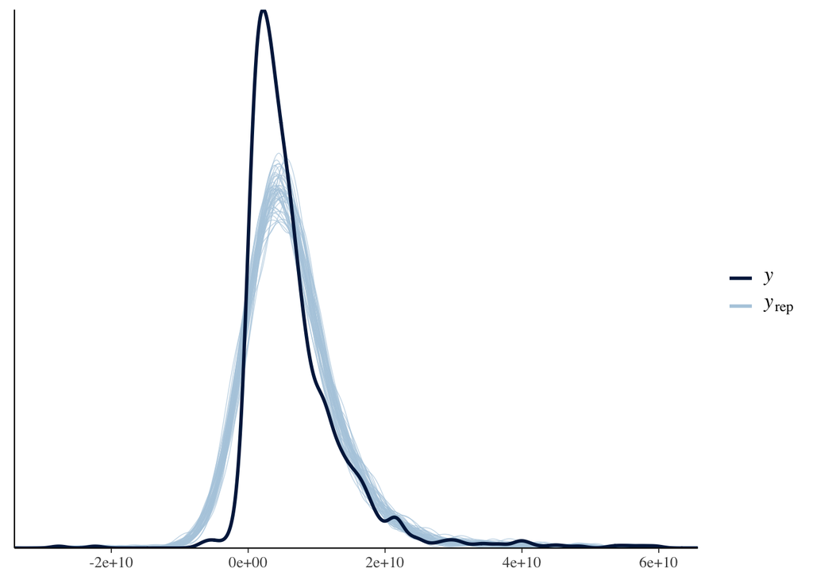

```r
model_2 <- update(model_2_prior_with_hiar, prior_PD = FALSE, refresh = 0)
pp_check(model_2)
```

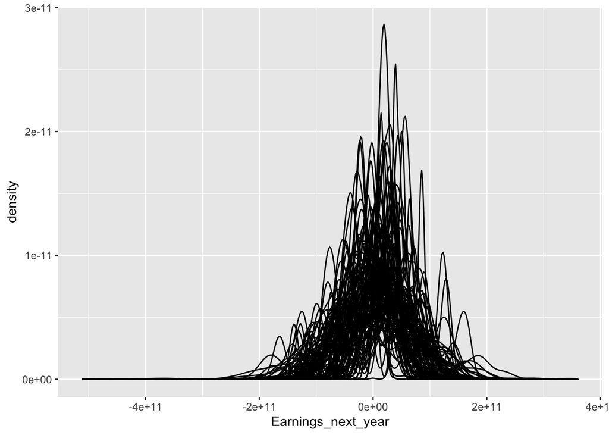

```r
top_50_update%>%
  add_predicted_draws(model_2_prior_with_hiar, n = 100) %>%
  ggplot(aes(x = Earnings_next_year)) +
    geom_density(aes(x = .prediction, group = .draw))
```

Check the accuracy of the model:

```r
tidy(model_2, effects = "fixed", conf.int = TRUE, conf.level = 0.80)
```

```
## # A tibble: 8 × 5
##   term                         estimate std.error conf.low conf.high
##   <chr>                           <dbl>     <dbl>    <dbl>     <dbl>
## 1 (Intercept)                   2.60e+9   5.06e+8  1.96e+9   3.29e+9
## 2 EARNINGS                      8.92e-1   2.19e-2  8.63e-1   9.18e-1
## 3 SectorConsumer Discretionary -1.84e+9   6.44e+8 -2.70e+9  -1.02e+9
## 4 SectorConsumer Staples       -1.48e+9   6.36e+8 -2.31e+9  -6.56e+8
## 5 SectorFinancials             -1.57e+9   5.61e+8 -2.31e+9  -8.65e+8
## 6 SectorHealth Care            -1.75e+9   5.62e+8 -2.50e+9  -1.03e+9
## 7 SectorIndustrials            -1.95e+9   6.60e+8 -2.82e+9  -1.11e+9
## 8 SectorInformation Technology -1.15e+9   5.47e+8 -1.87e+9  -4.50e+8
```

```r
tidy(model_2, effects = "ran_pars")
```

```
## # A tibble: 2 × 3
##   term                    group       estimate
##   <chr>                   <chr>          <dbl>
## 1 sd_(Intercept).COMPANY  COMPANY   451700482.
## 2 sd_Observation.Residual Residual 3857938155.
```

The prediction for the model:

```r
pred <- posterior_predict(model_2, newdata = top_50_update %>% filter(YEAR == 2020))
```

The final model: using Bayesian forecasting:

Here, right now, we can only predict one variable only. We will try to predict for the whole dataset in the future.

```r
library(bayesforecast)
```

```r
ts_model <- function(company) {
  newdata <- data %>%
    filter(COMPANY == company) %>%
    select(EARNINGS) %>%
    arrange(EARNINGS)
  #head(newdata)
}

ts_model(company = "AMZN")
```

```r
AMZN <- data %>%
  filter(COMPANY == 'AMZN') %>%
  select(EARNINGS) %>%
  arrange(EARNINGS)

vector <- AMZN$EARNINGS

myts <- ts(vector, start=c(1999), end=c(2021), frequency=1)

sf1 = stan_sarima(ts = myts,order = c(1,1,1),seasonal = c(1,1,1),
                  prior_mu0 = student(mu = 0,sd = 1,df = 7))
sf1
```

```
##
## y ~ Sarima(1,1,1)
## 23 observations and 1 dimension
## Differences: 1 seasonal Differences: 0
## Current observations: 22
##
##                 mean           se            5%           95%      ess   Rhat
## mu0    -1.300000e-03       0.0194 -1.934500e+00  1.912300e+00 3983.392 0.9999
## sigma0  2.074936e+09 5029601.6025  1.617109e+09  2.631126e+09 3824.876 1.0037
## ar      6.677000e-01       0.0056 -8.800000e-02  9.833000e-01 3485.341 1.0042
## ma     -2.645000e-01       0.0042 -6.213000e-01  2.540000e-01 3477.687 1.0033
## loglik -5.064757e+02       0.0289 -5.097076e+02 -5.040934e+02 4063.978 1.0008
##
##  Samples were drawn using sampling(NUTS). For each parameter, ess
##  is the effective sample size, and Rhat is the potential
##  scale reduction factor on split chains (at convergence, Rhat = 1).
```

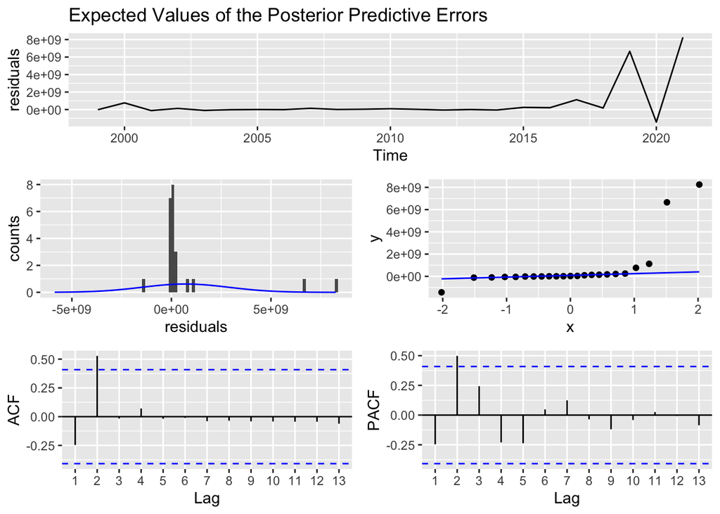

```r
check_residuals(sf1)
```

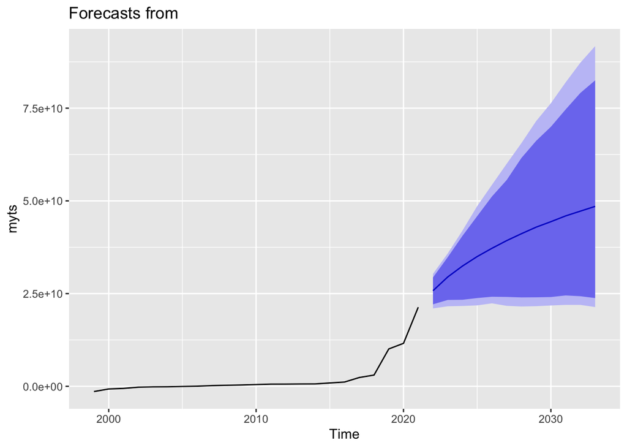

```r
autoplot(forecast(object = sf1,h = 12))
```

# 5. Next steps

Identify your next steps. What improvements do you plan to make? Are there any ways you plan to enhance your presentation of this analysis (eg: shiny apps, animations, engaging graphics)?

We plan on continuing to focus on improving our hierarchical model in the coming phases. We hope to improve it so it better models the data and has better predictive accuracy. We are still thinking about how we will go about presenting our project and in what medium we will do it in. We are leaning towards more of a blog post type of work as this may be better suited for a broader audience that could be interested in our project.

# 6. Participation

• If your project group is working on a collaborative project, specify what eachg roupmember (including yourself) contributed to this checkpoint.

Duc: Gathering/cleaning data, building hierarchical model, general visualization input Nick: Created data visualizations, helped w/ model building, general project input Nolan: Created data visualizations, helped w/ model building, project checkpoint doc.